# speaq 2.0 function illustrations

Charlie Beirnaert

2018-07-03

## speaq 2.0

To illustrate the possibilities of speaq 2.0, the wine dataset is used (available form the University of Copenhagen at models.life.ku.dk). This dataset is also utilized in the paper so with this vignette you will be able to reproduce the results.

Before we start with the example let’s first recap what the new method in speaq 2.0 encompass:

1. Peak detection: `getWaveletPeaks()`
2. Peak grouping: `PeakGrouper()`
3. Peak filling: `PeakFilling()`
4. Feature matrix construction: `BuildFeatureMatrix()`

### Plotting the raw wine data

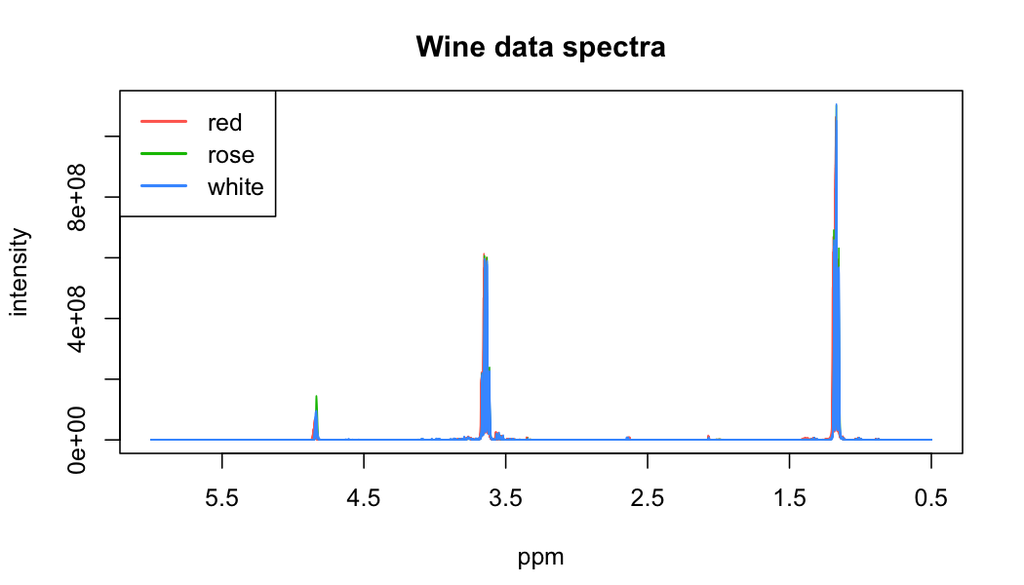

```r
library(speaq)
data(Winedata)
Spectra.wine <- as.matrix(Winedata$spectra )
ppm.wine <- as.numeric(Winedata$ppm)
wine.color <- Winedata$wine.color
wine.origin <- Winedata$origin
# all spectra
speaq::drawSpecPPM(Y.spec = Spectra.wine,
                   X.ppm = ppm.wine,
                   title = 'Wine data spectra',
                   groupFactor = wine.color,
                   legend.extra.x = 1,
                   legend.extra.y = 1.1)
```

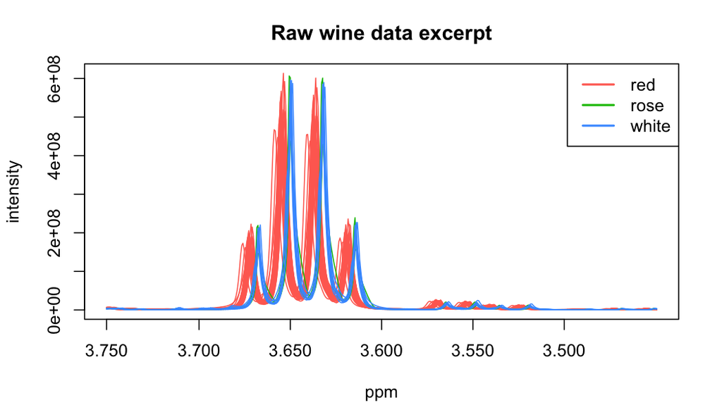

```r
# small excerpt by defining the region of interest
speaq::drawSpecPPM(Y.spec = Spectra.wine,
                   X.ppm = ppm.wine,
                   groupFactor = as.factor(wine.color),
                   title = 'Raw wine data excerpt',
                   legend.extra.x = 1.1,
                   legend.extra.y = 1.0,
                   ROI.ppm = 3.6,
                   ROI = NULL,
                   roiWidth.ppm = 0.15,
                   legendpos = "topright" )
```

### From spectra via peaks to peak groups (features)

```r
wine.peaks <- speaq::getWaveletPeaks(Y.spec=Spectra.wine,
                                     X.ppm=ppm.wine,
                                     baselineThresh = 10,
                                     SNR.Th = -1,
                                     nCPU = 2,
                                     include_nearbyPeaks = TRUE) # nCPU set to 2 for the vignette build


wine.grouped <- speaq::PeakGrouper(Y.peaks = wine.peaks,
                                   min.samp.grp = 5,
                                   grouping.window.width = 200)
```

There are two notes to be made on some important parameters: 1. The `include_nearbyPeaks = TRUE` option also detects peaks in the tails of larger other peaks. At first this might seem the prefered option as you want to detect as much peaks as possible but we will see later that often it is better to exclude them as these small peaks can cause problems later on. 2. The `grouping.window.width` parameter is chosen to be twice the size of the default value: it is advised to choose this larger when working with spectra that exhibit large between sample shifts. The wine dataset is an extreme example of large between sample shifts (caused by the substantial pH differences between wines of different colour)

Now we can plot the detected peaks and the grouped peaks. The dataset after grouping contains both the original ppm values of every peak (in the `peakPPM` variable) but also the group information (found in the `peakIndex` variable). By calling the `AddPlottingStuff()` function the groupPPM variable is added so we also have the ppm value of the groups (the link is: `groupPPM <- ppm.wine[peakIndex]`)

### Plotting the peak data

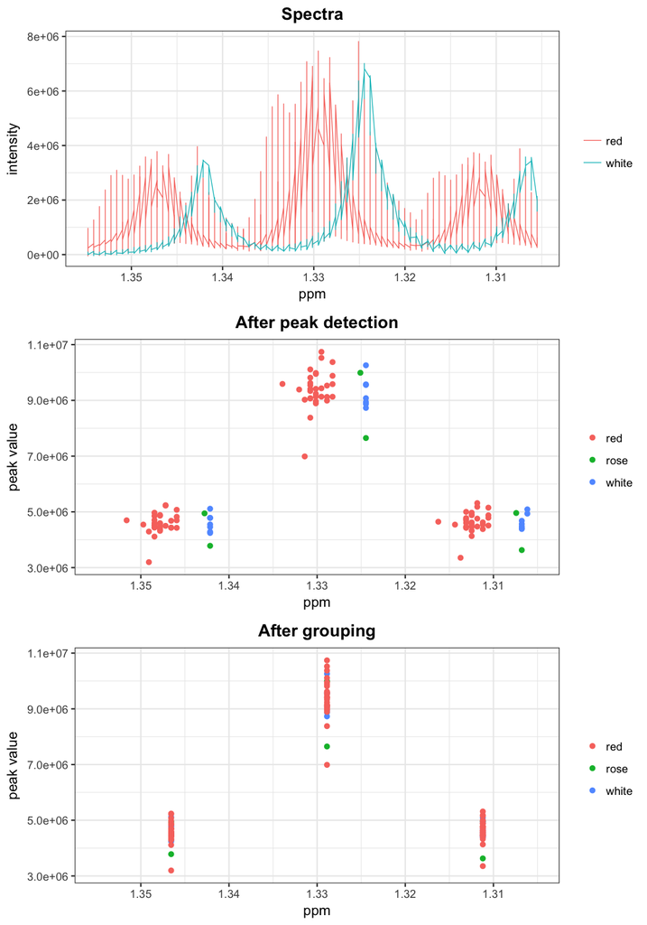

```r
# adding labels to the dat a for plotting and the group ppm values
library(ggplot2)
ROI.ppm <- 1.330
roiWidth.ppm <- 0.025

speaq::ROIplot(Y.spec = Spectra.wine,
               X.ppm = ppm.wine,
               ungrouped.peaks = wine.peaks,
               grouped.peaks = wine.grouped,
               ROI.ppm = ROI.ppm,
               roiWidth.ppm = roiWidth.ppm,
               groupLabels = as.factor(wine.color))
```

The plot above shows clearly what the basis of speaq 2.0 does, convert spectra accurately to peak data and group these peaks. The quality of the grouping can be checked by plotting the silhouette values. this can be done with the `SilhouetR()` function.

```r
SilhouetteValues <- speaq::SilhouetR(DataMatrix = wine.grouped$peakPPM,
                                     GroupIndices = wine.grouped$peakIndex)
```

```
## DataMatrix is not a matrix, attempting conversion with the assumption of only 1 variable (1 column)
```

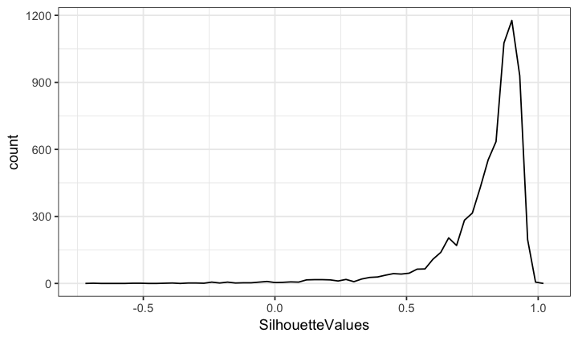

```r
Silh_plot <- ggplot(SilhouetteValues, aes(SilhouetteValues)) +
             geom_freqpoly(binwidth = 0.03) +
             theme_bw()
Silh_plot
```

It is clear that the grouping is very good. To be absolutely shure we can check the mean silhouette value of every group to see if there are groups that should be regrouped. This regrouping, if needed, can be done with the `regroupR()` function.

```r
groups <- unique(SilhouetteValues$GroupIndices)
Ngroups <- length(groups)
sil_means <- matrix(NA, ncol = 3, nrow = Ngroups)

for (k in 1:Ngroups) {
    sil_means[k, 1] = groups[k]
    sil_means[k, 2] = mean(SilhouetteValues$SilhouetteValues[SilhouetteValues$GroupIndices ==
        groups[k]])
    sil_means[k, 3] = mean(wine.grouped$peakSNR[wine.grouped$peakIndex == groups[k]])
}

sil_means <- sil_means[order(sil_means[, 2]), ]
colnames(sil_means) <- c("groupIndex", "avg_silhouette_val", "avg. SNR")
head(sil_means)
```

```
##      groupIndex avg_silhouette_val  avg. SNR
## [1,]       5313          0.2557844 32.261401
## [2,]       5050          0.4549954 11.669748
## [3,]       2330          0.4848325 31.757387
## [4,]       4711          0.4904269  5.754990
## [5,]       5552          0.5011936  6.933832
## [6,]       3287          0.5099114  3.559727
```

As it turns out, there is a group with a low average silhouette value (0.25) but a fairly high average signal-to-noise ratio (if this group had a low SNR ratio it could just be a noise group). This indicates that these are non-noise peaks which are grouped incorrectly, the follwoing plot acknowledges this

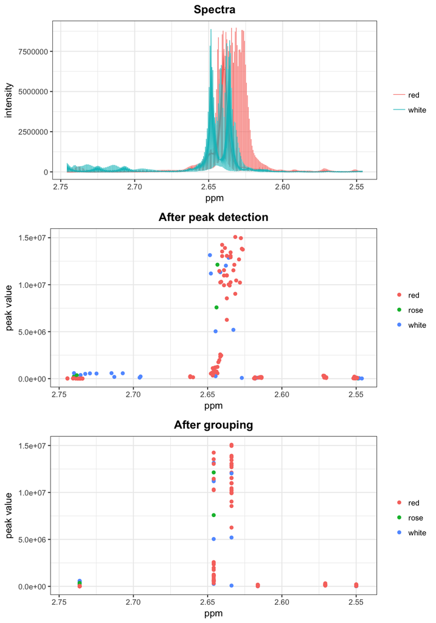

```r
faulty.groupIndex <- sil_means[1,1]
ROI.ppm <- ppm.wine[faulty.groupIndex]
roiWidth.ppm <- 0.1

speaq::ROIplot(Y.spec = Spectra.wine,
               X.ppm = ppm.wine,
               ungrouped.peaks = wine.peaks,
               grouped.peaks = wine.grouped,
               ROI.ppm = ROI.ppm,
               roiWidth.ppm = roiWidth.ppm,
               groupLabels = as.factor(wine.color))
```

Clearly the large peaks and small peaks are grouped together because of the large shifts in the wine dataset making the small and large peaks overlap, this messes up the grouping. There are multiple ways to solve this issue:

1. By setting `include_nearbyPeaks = FALSE` in the `getWaveletPeaks()` function these small peaks in the tails of large peaks will not be included, although some other peaks might also be missed. Or
2. by selecting the wrong group and submitting them to the `regroupR()` function. This will use both the ppm values and the peak signal-to-noise ratio for the initial between peak distance calculation and group them according to this distance.

```r
wrong.groups <- sort(sil_means[sil_means[,1]>=sil_means[1,1],1])[1:2]

wine.regrouped <- speaq::regroupR(grouped.peaks = wine.grouped,
                                  list.to.regroup = wrong.groups,
                                  min.samp.grp = 5,
                                  max.dupli.prop = 0.1)
```

```
## 'list.to.regroup' is not a list. Assuming it is a list with only one element.
```

The plot below reveals the problem is clearly fixed now, but it requires more user interaction than wanted.

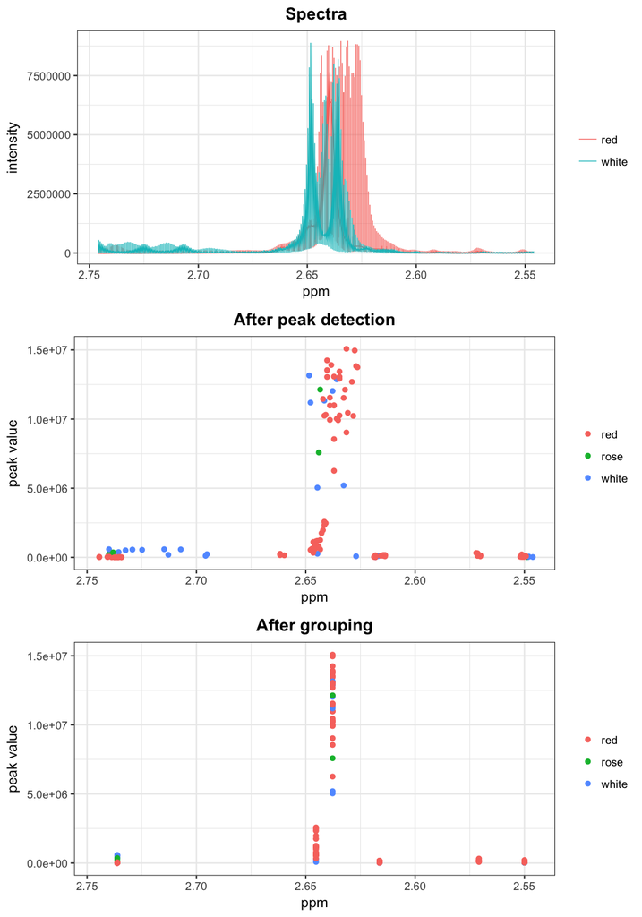

```r
faulty.groupIndex <- sil_means[1,1]
ROI.ppm <- ppm.wine[faulty.groupIndex]
roiWidth.ppm <- 0.1



speaq::ROIplot(Y.spec = Spectra.wine,
               X.ppm = ppm.wine,
               ungrouped.peaks = wine.peaks,
               grouped.peaks = wine.regrouped,
               ROI.ppm = ROI.ppm,
               roiWidth.ppm = roiWidth.ppm,
               groupLabels = as.factor(wine.color))
```

With this peaks regrouped we can continu the analysis. first peak filling is applied and secondly the grouped peak data is converted to a so called feature matrix with samples for rows and features (peak groups) for columns whereby 1 matrix element indicates the peakvalue for a specific group and sample combo.

```r
wine.filled <- speaq::PeakFilling(Y.grouped = wine.regrouped,
                                  Y.spec = Spectra.wine,
                                  max.index.shift = 200,
                                  nCPU = 2) # nCPU set to 1 for the vignette build

wine.Features <- speaq::BuildFeatureMatrix(wine.filled)
```

Now that we have these peak data they can either be incorporated in larger metabolomic experiments, where NMR spectroscopy data is often combined with LC-MS data (which is processed always in peak data format), or it can be anaysed on its own, as we will demonstrate here.

### Intermezzo: PCA

Now that we have the feature matrix we can quickly perform a PCA (principal component analysis) as a way of visualising potential trends and groups in the data. Before any PCA it is advised to scale and center the data, here we will use the pareto scaling but other are available (see the `SCANT()` helpfile)

```r
wine.Features.scaled <- speaq::SCANT(data.matrix = wine.Features,
                                     type = c("pareto", "center"))
```

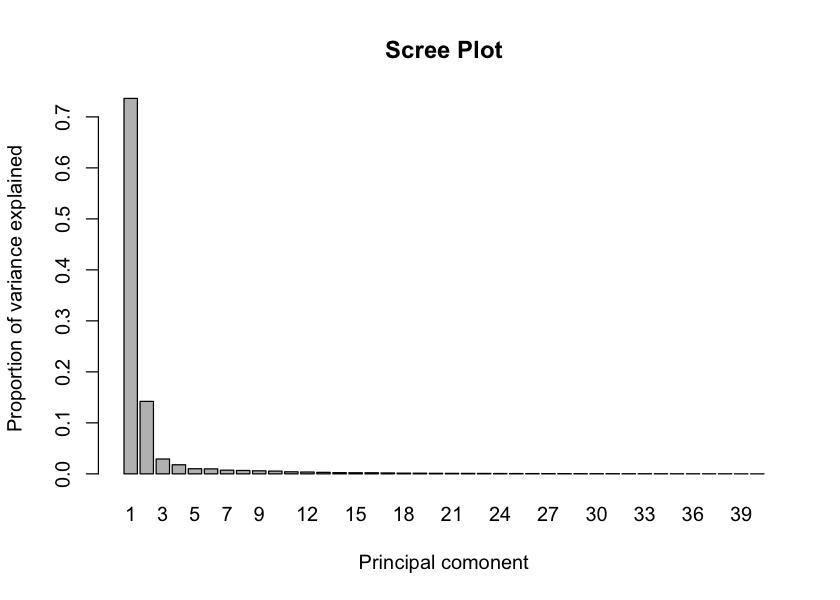

```r
common.pca <- prcomp(wine.Features.scaled)


loadings <- common.pca$rotation
scores <- common.pca$x
varExplained <- common.pca$sdev^2

barplot(varExplained/sum(varExplained),
        main="Scree Plot",ylab="Proportion of variance explained",
        xlab = "Principal comonent",
        names.arg = as.character(seq(1,length(varExplained))))
```

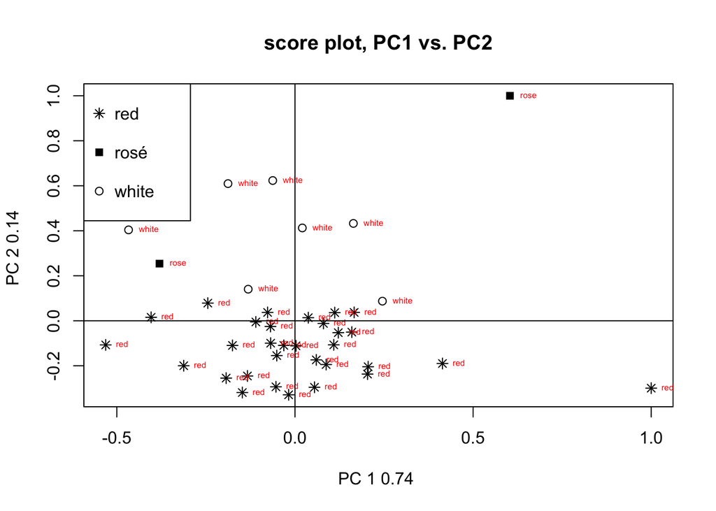

```r
plot.marks <- as.numeric(wine.color)
plot.marks[plot.marks == 1] <- 8
plot.marks[plot.marks == 2] <- 15
plot.marks[plot.marks == 3] <- 1

cp1 <- 1
cp2 <- 2
plot(scores[,cp1]/max(scores[,cp1]), scores[,cp2]/max(scores[,cp2]),
     main=paste("score plot, PC",cp1," vs. PC",cp2,sep=""),
     xlab=paste("PC",cp1,round(varExplained[cp1]/sum(varExplained),digits=2),""),
     ylab=paste("PC",cp2,round(varExplained[cp2]/sum(varExplained),digits=2),""),
     pch = plot.marks)
text(scores[,cp1]/max(scores[,cp1]),scores[,cp2]/max(scores[,cp2]), wine.color, cex=0.5, pos=4, col="red")
lines(x = c(-100,100), y = c(0,0))
lines(x = c(0,0), y = c(-100,100))
legend("topleft",
       legend = c("red  ","rosé  ","white      "),
       pch = c(8,15,1),
       y.intersp = 1.9)
```

From the PCA analysis it is already clear that there is a large difference between on the one side red wine and on the other side white and rosé wine.

Next we can use the `relevant.features()` function in speaq which uses linear models to produce a p-value corresponding to the nulhypothesis that feature x is not related to the outcome vector. After a p-value correction for multiple testing (as with increasing numbers of even randomly generated features some will eventually be significantly related to the output vector) we can identify the relevant features. As noted in the paper this method is perfectly suited for outcome vectors containing either 2 classes or more classes with a numeric relationship. This is unfortunately not the case here as red, white and rosé are 3 categorical variables. Since there are only 2 rosé wines we will perform the analysis leaving these ones out. This does require however to rescale the raw data without the rosé wines, as otherwise they still have an influence on the dataset ### removing the rose wine

```r
red.white.scaled <- speaq::SCANT(wine.Features[wine.color!="rose",],
                                 type = c("pareto", "center"))

red.white.colors <- as.factor(as.character(wine.color)[wine.color!="rose"])
```

### A differential analysis based on linear models

```r
p.all_bonf <- speaq::relevant.features.p(datamatrix = red.white.scaled,
                                         responsevector = red.white.colors,
                                         p.adj = "bonferroni")
```

```
## [1] "response was transformed to numeric"
```

```r
significant.features <- p.all_bonf[p.all_bonf$p.values<=0.05, ]

# order from most significant
significant.features <- significant.features[order(significant.features[,2]),]
head(significant.features)
```

```
##     index     p.values
## 117  4928 4.073222e-09
## 116  4901 4.670077e-09
## 125  5146 1.835604e-08
## 126  5170 7.929646e-07
## 93   4201 8.326499e-07
## 76   3518 2.613718e-06
```

It is clear that there are features well below the 0.05 p-value threshold. This was to be expected as the difference between the two classes was already apparent in the PCA analysis. Often when the PCA analysis does not reveal obvious results the differential analysis bases on linear models will nonetheless find significant features. We can now easily find which features correspond to the low p-values and consequently plot them.

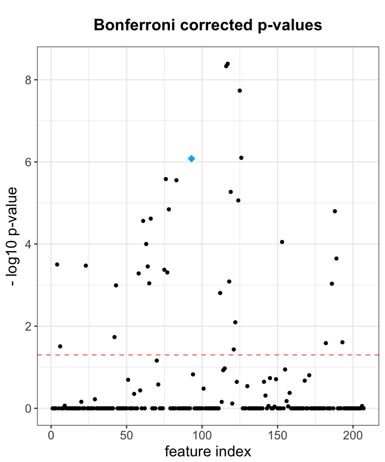

```r
peak_of_interest <- 5 # change this to the peak you want

interest.groupIndex <- significant.features$index[peak_of_interest]
interest.peakIndex <- as.numeric(rownames(significant.features))[peak_of_interest]


ROI.ppm <- ppm.wine[interest.groupIndex]
roiWidth.ppm <- 0.03


ggplot(p.all_bonf, aes(x=as.numeric(rownames(p.all_bonf)), y= -log10(p.values) )) +
       geom_point(data = p.all_bonf[-interest.peakIndex,],
                  aes(x=as.numeric(rownames(p.all_bonf[-interest.peakIndex,])), y= -log10(p.values) ),
                  shape = 16) +
       geom_point(data = p.all_bonf[interest.peakIndex,],  aes(x=interest.peakIndex, y= -log10(p.values) ),
                  shape = 18,
                  size = 3,
                  colour ="#00B0F6" ) +
       xlab("feature index") +
       ylab("- log10 p-value") +
       ggtitle("Bonferroni corrected p-values") +
       geom_hline(aes(yintercept= -log10(0.05), color="red"),linetype = 2) +
       guides(color=FALSE) +
       theme_bw() +
       theme(plot.title = element_text(lineheight = 0.8, face="bold", margin = margin(12,0,13,0),hjust = 0.5, size = 15),
             text = element_text(size=14))
```

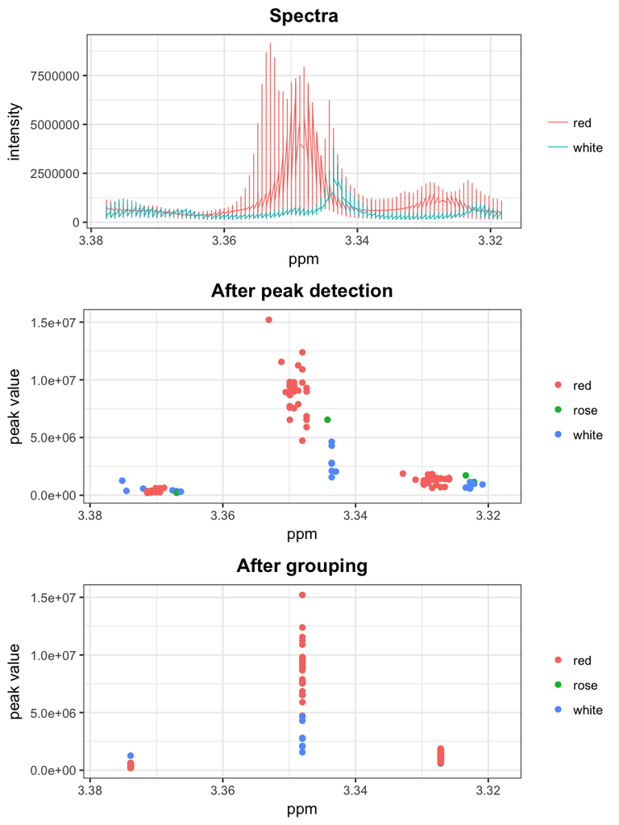

```r
speaq::ROIplot(Y.spec = Spectra.wine,
               X.ppm = ppm.wine,
               ungrouped.peaks = wine.peaks,
               grouped.peaks = wine.regrouped,
               ROI.ppm = ROI.ppm,
               roiWidth.ppm = roiWidth.ppm,
               groupLabels = as.factor(wine.color))
```

Or just plot the spectra of a single feature

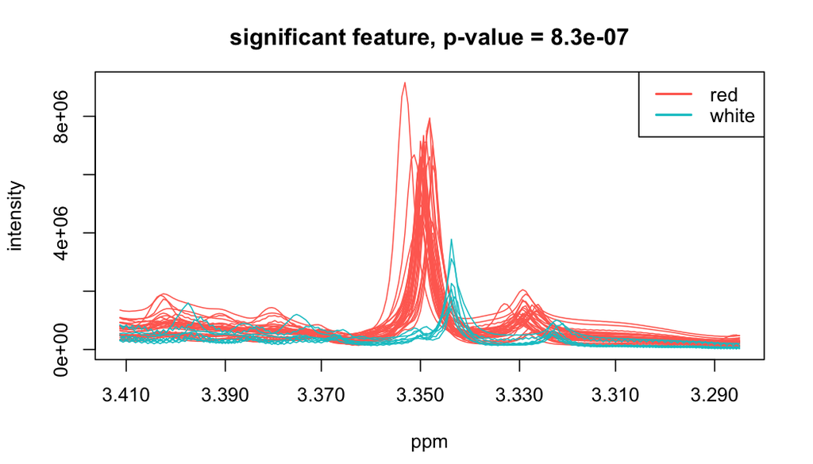

```r
peak_of_interest <- 5# change this number to any of the peaks you want to see
drawSpecPPM(Y.spec = Spectra.wine[wine.color != "rose", ],
            X.ppm = ppm.wine,
            groupFactor = red.white.colors,
            title = paste("significant feature, p-value =",
                          format(significant.features$p.values[peak_of_interest],
                                 scientific = TRUE,
                                 digits=2),
                          sep=" "),
            legend.extra.x = 1.1,
            legend.extra.y = 0.9,
            ROI = significant.features$index[peak_of_interest],
            roiWidth = 100,
            legendpos = "topright" )
```

Now that we have identified relevant features we can use the original `speaq` package to plot the spectra more clearly. Specifically we can use the `dohCluster()` function from `speaq` to align the raw spectra and consequently plot these with the `drawSpecPPM()` function as in the plot above.

```r
peakList <- speaq::detectSpecPeaks(as.matrix(Spectra.wine),
                                   nDivRange = 128,
                                   scales = seq(1, 16, 2),
                                   baselineThresh = 100,
                                   SNR.Th = -1,
                                   verbose=FALSE)
```

[output not shown]

[output cut: 8387 more lines]

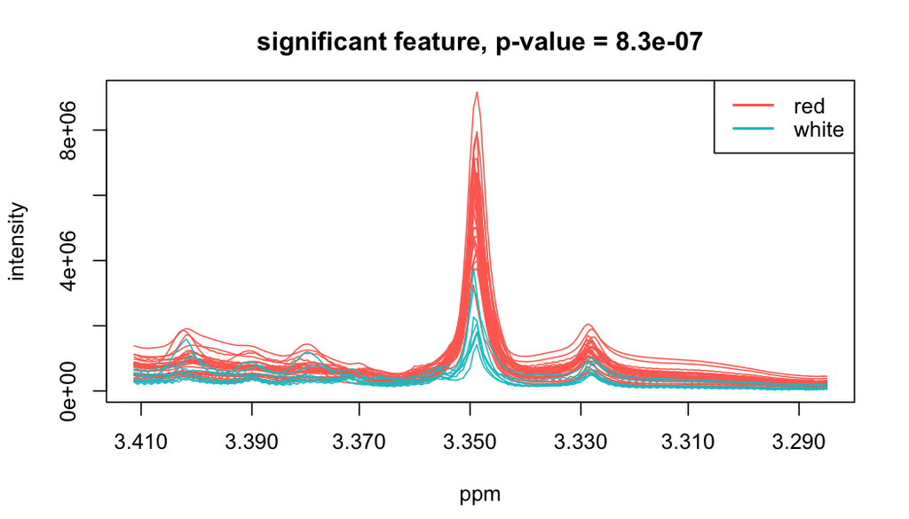

```r
resFindRef <- findRef(peakList)
refInd <- resFindRef$refInd

aligned.spectra <- speaq::dohCluster(as.matrix(Spectra.wine),
                                     peakList = peakList,
                                     refInd = refInd,
                                     maxShift  = 200,
                                     acceptLostPeak = TRUE, verbose=FALSE)


speaq::drawSpecPPM(Y.spec = aligned.spectra[wine.color != "rose", ],
                   X.ppm = ppm.wine,
                   groupFactor = red.white.colors,
                   title = paste("significant feature, p-value =",
                                 format(significant.features$p.values[peak_of_interest],
                                        scientific = TRUE,
                                        digits=2),
                                 sep=" "),
                   legend.extra.x = 1.1,
                   legend.extra.y = 0.9,
                   ROI = significant.features$index[peak_of_interest],
                   roiWidth = 100,
                   legendpos = "topright" )
```